# Machine Learning Engineer Nanodegree

## Predict Stock Prices

### Load Necessary Libraries

```python
#import libraries
import numpy as np
import pandas as pd
import tensorflow as tf
from time import time
from IPython.display import display


from keras.models import Sequential
from keras.layers import Dense,Dropout,Activation
from keras.layers import LSTM, Bidirectional
from keras.callbacks import ModelCheckpoint, EarlyStopping
import keras

import matplotlib.pyplot as plt
from sklearn.metrics import mean_squared_error
from ipy_table import *
```

```python
%matplotlib inline
```

```python
#Data path

SP500_file_path = 'data/SP500.csv'


IBM_file_path = 'data/IBM.csv'
MSFT_file_path = 'data/MSFT.csv'
WMT_file_path = 'data/WMT.csv'
PFE_file_path = 'data/PFE.csv'
MYL_file_path = 'data/MYL.csv'
XOM_file_path = 'data/XOM.csv'

AAPL_file_path = 'data/AAPL.csv'# AAPL row 167 cntains null
GOOG_file_path = 'data/GOOG.csv'
```

## Read Data

```python
data_SP500 = pd.read_csv(SP500_file_path,index_col ='Date')

data_IBM = pd.read_csv(IBM_file_path,index_col ='Date')
data_MSFT = pd.read_csv(MSFT_file_path,index_col ='Date')
data_PFE = pd.read_csv(PFE_file_path,index_col ='Date')
data_WMT = pd.read_csv(WMT_file_path,index_col ='Date')
data_XOM = pd.read_csv(XOM_file_path,index_col ='Date')
data_MYL = pd.read_csv(MYL_file_path,index_col ='Date')

data_AAPL = pd.read_csv(AAPL_file_path,index_col ='Date')
data_GOOG = pd.read_csv(GOOG_file_path,index_col ='Date')
```

```python
data_SP500 = data_SP500[pd.notnull(data_SP500['Adj Close'])]

data_IBM = data_IBM[pd.notnull(data_IBM['Adj Close'])]
data_MSFT = data_MSFT[pd.notnull(data_MSFT['Adj Close'])]
data_PFE = data_PFE[pd.notnull(data_PFE['Adj Close'])]
data_WMT = data_WMT[pd.notnull(data_WMT['Adj Close'])]
data_XOM = data_XOM[pd.notnull(data_XOM['Adj Close'])]
data_MYL = data_MYL[pd.notnull(data_MYL['Adj Close'])]

data_AAPL = data_AAPL[pd.notnull(data_AAPL['Adj Close'])]
data_GOOG = data_GOOG[pd.notnull(data_GOOG['Adj Close'])]
```

```python
data_SP500 = data_SP500.dropna()
data_IBM = data_IBM.dropna()
data_MSFT = data_MSFT.dropna()
data_PFE = data_PFE.dropna()
data_WMT = data_WMT.dropna()
data_XOM = data_XOM.dropna()
data_MYL = data_MYL.dropna()

data_AAPL = data_AAPL.dropna()
data_GOOG = data_GOOG.dropna()
```

```python
data_SP500.head()
```

| Date | Open | High | Low | Close | Adj Close | Volume |
| --- | --- | --- | --- | --- | --- | --- |
| 1980-12-12 | 127.360001 | 129.979996 | 127.150002 | 129.229996 | 129.229996 | 39530000 |
| 1980-12-15 | 129.229996 | 131.330002 | 128.639999 | 129.449997 | 129.449997 | 39700000 |
| 1980-12-16 | 129.449997 | 131.220001 | 128.330002 | 130.600006 | 130.600006 | 41630000 |
| 1980-12-17 | 130.600006 | 133.589996 | 130.220001 | 132.889999 | 132.889999 | 50800000 |
| 1980-12-18 | 132.889999 | 135.899994 | 131.889999 | 133.000000 | 133.000000 | 69570000 |

```python
data_SP500.tail()
```

| Date | Open | High | Low | Close | Adj Close | Volume |
| --- | --- | --- | --- | --- | --- | --- |
| 2017-06-30 | 2429.199951 | 2432.709961 | 2421.649902 | 2423.409912 | 2423.409912 | 3361590000 |
| 2017-07-03 | 2431.389893 | 2439.169922 | 2428.689941 | 2429.010010 | 2429.010010 | 1962290000 |
| 2017-07-05 | 2430.780029 | 2434.899902 | 2422.050049 | 2432.540039 | 2432.540039 | 3367220000 |
| 2017-07-06 | 2423.439941 | 2424.280029 | 2407.699951 | 2409.750000 | 2409.750000 | 3364520000 |
| 2017-07-07 | 2413.520020 | 2426.919922 | 2413.520020 | 2425.179932 | 2425.179932 | 2901330000 |

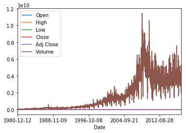

```python
data_SP500.plot()
```

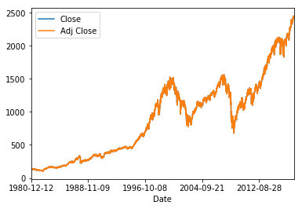

```python
data_SP500[['Close','Adj Close']].plot()
```

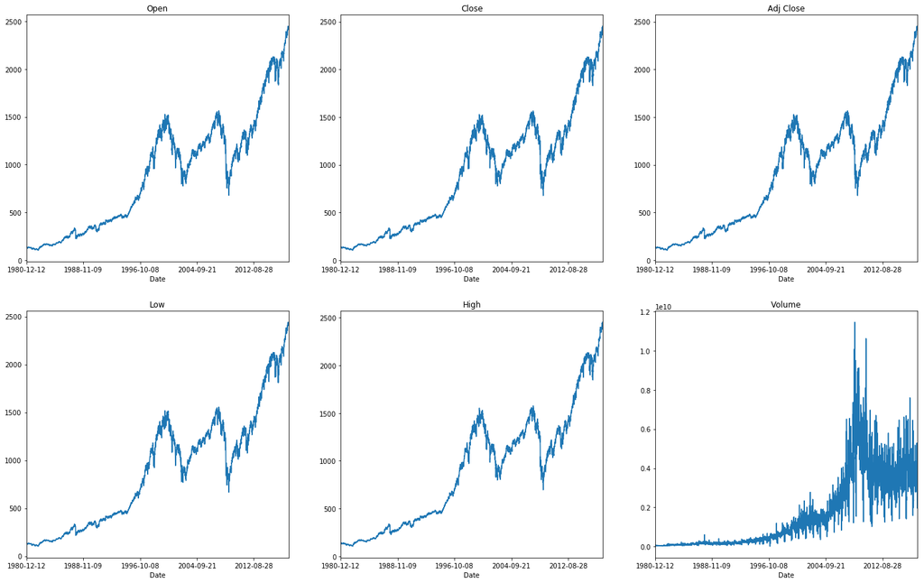

```python
fig = plt.figure(figsize = (24,15))
ax1 = fig.add_subplot(2,3,1)
data_SP500['Open'].plot(ax=ax1, title = "Open")


ax2 = fig.add_subplot(2,3,2)
data_SP500['Close'].plot(ax=ax2, title = "Close")

ax3 = fig.add_subplot(2,3,3)
data_SP500['Adj Close'].plot(ax=ax3, title = "Adj Close")

#fig = plt.figure(figsize = (15,8))
ax1 = fig.add_subplot(2,3,4)
data_SP500['Low'].plot(ax=ax1, title = "Low")

ax2 = fig.add_subplot(2,3,5)
data_SP500['High'].plot(ax=ax2, title = "High")

ax3 = fig.add_subplot(2,3,6)
data_SP500['Volume'].plot(ax=ax3, title = "Volume")
```

#### From above graphs, it is clear that Open, Close, AdjClose, High and low follow almost same pattern, So I planned to take only Adj Close for prediction. I calculated DailyReturn and used AdjClose as inputs also, but there was not much difference in the results. So to keep it simple and getting very impressive results with only AdjClose value, I rested with using only Adj Close for prediction.

#### Daily Return calculation and merging it with AdjClose is shown below to make 2 column input dataset.

### For this problem, I have tried to create a data dependency by making any day AdjClose value to be dependent upon previous days AdjClose values. I tried dependency windows to be 5, 10, 15, 50, 75 and 100 [ this means that current AdjClose value is dependent upon previous 5 or 10 or 15 or 50 or 75 or 100 days]. This dependency window will actually make the input features. So with a 5 days window, it means output AdjClose predicted value is dependent upon last 5 days.

```python
data_SP500_AdjClose = data_SP500['Adj Close']
data_IBM_AdjClose = data_IBM['Adj Close']

data_MSFT_AdjClose = data_MSFT['Adj Close']
data_PFE_AdjClose = data_PFE['Adj Close']
data_WMT_AdjClose = data_WMT['Adj Close']
data_XOM_AdjClose = data_XOM['Adj Close']
data_MYL_AdjClose = data_MYL['Adj Close']

data_AAPL_AdjClose = data_AAPL['Adj Close']
data_GOOG_AdjClose = data_GOOG['Adj Close']
```

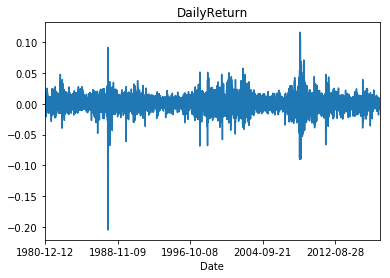

```python
dailyReturn_SP500 = data_SP500_AdjClose/data_SP500_AdjClose.shift(1) - 1
dailyReturn_SP500[0] = 0.0
dailyReturn_SP500.plot(title='DailyReturn')
```

```python
frames = [data_SP500_AdjClose, dailyReturn_SP500]
data_SP500_merged = pd.concat(frames,axis=1)
data_SP500_merged.columns = ['AdjClose', 'DailyReturn']
```

```python
data_SP500_merged.head()
```

| Date | AdjClose | DailyReturn |
| --- | --- | --- |
| 1980-12-12 | 129.229996 | 0.000000 |
| 1980-12-15 | 129.449997 | 0.001702 |
| 1980-12-16 | 130.600006 | 0.008884 |
| 1980-12-17 | 132.889999 | 0.017534 |
| 1980-12-18 | 133.000000 | 0.000828 |

## Normalizing Data

#### Different scalars are used for each stock dataset so that these can be used later(if needed) to recover original values

```python
from sklearn.preprocessing import MinMaxScaler
minmaxScaler_SP500 = MinMaxScaler((0,1))

values = data_SP500_AdjClose.values
index = data_SP500_AdjClose.index

values = minmaxScaler_SP500.fit_transform(values.reshape(-1,1))

normalized_data_SP500_AdjClose = pd.DataFrame(values, index = index)
```

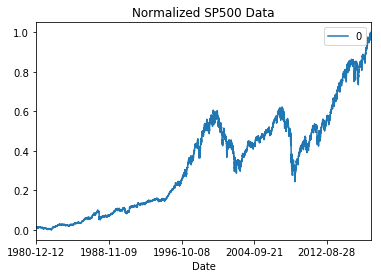

```python
normalized_data_SP500_AdjClose.plot(title = "Normalized SP500 Data")
```

```python
minmaxScaler_IBM = MinMaxScaler((0,1))

values = data_IBM_AdjClose.values
index = data_IBM_AdjClose.index

values = minmaxScaler_IBM.fit_transform(values.reshape(-1,1))

normalized_data_IBM_AdjClose = pd.DataFrame(values, index = index)
```

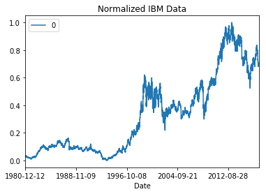

```python
normalized_data_IBM_AdjClose.plot(title = "Normalized IBM Data")
```

```python
minmaxScaler_MSFT = MinMaxScaler((0,1))

values = data_MSFT_AdjClose.values
index = data_MSFT_AdjClose.index

values = minmaxScaler_MSFT.fit_transform(values.reshape(-1,1))

normalized_data_MSFT_AdjClose = pd.DataFrame(values, index = index)
```

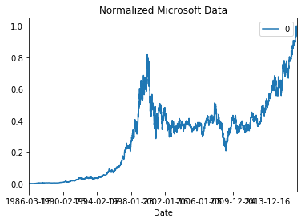

```python
normalized_data_MSFT_AdjClose.plot(title = "Normalized Microsoft Data")
```

```python
minmaxScaler_PFE = MinMaxScaler((0,1))

values = data_PFE_AdjClose.values
index = data_PFE_AdjClose.index

values = minmaxScaler_PFE.fit_transform(values.reshape(-1,1))

normalized_data_PFE_AdjClose = pd.DataFrame(values, index = index)
```

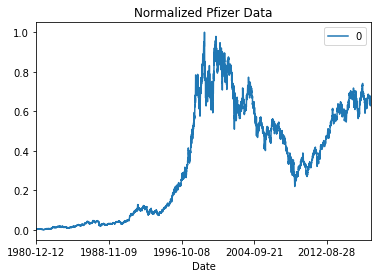

```python
normalized_data_PFE_AdjClose.plot(title = "Normalized Pfizer Data")
```

```python
minmaxScaler_WMT = MinMaxScaler((0,1))

values = data_WMT_AdjClose.values
index = data_WMT_AdjClose.index

values = minmaxScaler_WMT.fit_transform(values.reshape(-1,1))

normalized_data_WMT_AdjClose = pd.DataFrame(values, index = index)
```

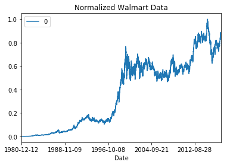

```python
normalized_data_WMT_AdjClose.plot(title = "Normalized Walmart Data")
```

```python
minmaxScaler_XOM = MinMaxScaler((0,1))

values = data_XOM_AdjClose.values
index = data_XOM_AdjClose.index

values = minmaxScaler_XOM.fit_transform(values.reshape(-1,1))

normalized_data_XOM_AdjClose = pd.DataFrame(values, index = index)
```

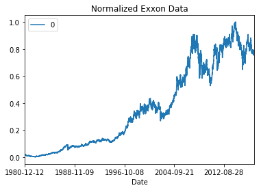

```python
normalized_data_XOM_AdjClose.plot(title = "Normalized Exxon Data")
```

```python
minmaxScaler_MYL = MinMaxScaler((0,1))

values = data_MYL_AdjClose.values
index = data_MYL_AdjClose.index

values = minmaxScaler_MYL.fit_transform(values.reshape(-1,1))

normalized_data_MYL_AdjClose = pd.DataFrame(values, index = index)
```

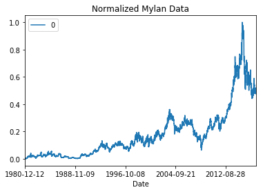

```python
normalized_data_MYL_AdjClose.plot(title = "Normalized Mylan Data")
```

```python
minmaxScaler_AAPL = MinMaxScaler((0,1))

values = data_AAPL_AdjClose.values
index = data_AAPL_AdjClose.index

values = minmaxScaler_AAPL.fit_transform(values.reshape(-1,1))

normalized_data_AAPL_AdjClose = pd.DataFrame(values, index = index)
```

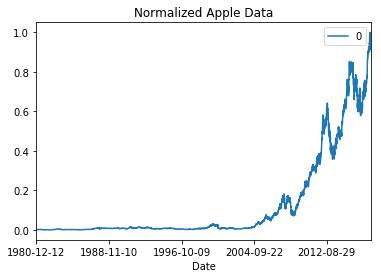

```python
normalized_data_AAPL_AdjClose.plot(title = "Normalized Apple Data")
```

```python
minmaxScaler_GOOG = MinMaxScaler((0,1))

values = data_GOOG_AdjClose.values
index = data_GOOG_AdjClose.index

values = minmaxScaler_GOOG.fit_transform(values.reshape(-1,1))

normalized_data_GOOG_AdjClose = pd.DataFrame(values, index = index)
```

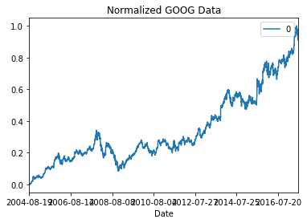

```python
normalized_data_GOOG_AdjClose.plot(title = "Normalized GOOG Data")
```

### Split Data into Training, Validation and Test Datasets

```python
def splitDataset(input_dataset):
    data_values = input_dataset.values
    data_size = len(input_dataset)

    train_test_split = int(np.ceil(8*data_size/float(10)))

    test_dataset = data_values[train_test_split:,:]
    #y_test = y[train_test_split+100:]

    train_valid_split = train_test_split - (data_size - train_test_split)

    train_dataset = data_values[:train_valid_split,:]
    #y_train = y[:train_valid_split]

    valid_dataset = data_values[train_valid_split:train_test_split,:]
    #y_valid = y[train_valid_split:train_test_split]
    return train_dataset, valid_dataset, test_dataset
```

```python
data_SP500_train, data_SP500_valid, data_SP500_test = splitDataset(normalized_data_SP500_AdjClose)

data_IBM_train, data_IBM_valid, data_IBM_test = splitDataset(normalized_data_IBM_AdjClose)
data_MSFT_train, data_MSFT_valid, data_MSFT_test = splitDataset(normalized_data_MSFT_AdjClose)
data_PFE_train, data_PFE_valid, data_PFE_test = splitDataset(normalized_data_PFE_AdjClose)
data_WMT_train, data_WMT_valid, data_WMT_test = splitDataset(normalized_data_WMT_AdjClose)
data_XOM_train, data_XOM_valid, data_XOM_test = splitDataset(normalized_data_XOM_AdjClose)
data_MYL_train, data_MYL_valid, data_MYL_test = splitDataset(normalized_data_MYL_AdjClose)
data_AAPL_train, data_AAPL_valid, data_AAPL_test = splitDataset(normalized_data_AAPL_AdjClose)
data_GOOG_train, data_GOOG_valid, data_GOOG_test = splitDataset(normalized_data_GOOG_AdjClose)
```

## Tranform Data to window dependency supervised data

```python
def window_transform_series(series, window_size):
    # containers for input/output pairs
    X = []
    y = []

    numWindows = len(series) - window_size

    for i in range(numWindows):
        lst = series[i:i + window_size]
        out = series[i + window_size]
        X.append(lst)
        y.append(out)


    # reshape each
    X = np.asarray(X)
    X.shape = (np.shape(X)[0:2])
    y = np.asarray(y)
    y.shape = (len(y),1)

    return X,y
```

### Window Size

```python
window_size = 5
```

### Train Dataset - Supervised

```python
X_train,y_train = window_transform_series(series=data_SP500_train,window_size = window_size)
```

### Valid Dataset - Supervised

```python
X_valid,y_valid = window_transform_series(series=data_SP500_valid,window_size = window_size)
```

### Test Dataset - Supervised

```python
X_test, y_test = window_transform_series(series=data_SP500_test,window_size = window_size)

X_test_IBM, y_test_IBM = window_transform_series(series=data_IBM_test,window_size = window_size)
X_test_MSFT, y_test_MSFT = window_transform_series(series=data_MSFT_test,window_size = window_size)
X_test_PFE, y_test_PFE = window_transform_series(series=data_PFE_test,window_size = window_size)
X_test_WMT, y_test_WMT = window_transform_series(series=data_WMT_test,window_size = window_size)
X_test_XOM, y_test_XOM = window_transform_series(series=data_XOM_test,window_size = window_size)
X_test_MYL, y_test_MYL = window_transform_series(series=data_MYL_test,window_size = window_size)
X_test_AAPL, y_test_AAPL = window_transform_series(series=data_AAPL_test,window_size = window_size)
X_test_GOOG, y_test_GOOG = window_transform_series(series=data_GOOG_test,window_size = window_size)
```

```python
X_train_initial = X_train
X_valid_initial = X_valid
X_test_initial = X_test
```

```python
dataset = np.vstack((data_SP500_train[:-5], data_SP500_valid[:-5], data_SP500_test[:-5]))
```

```python
X_train = np.asarray(np.reshape(X_train, (X_train.shape[0], window_size, 1)))
X_valid = np.asarray(np.reshape(X_valid, (X_valid.shape[0], window_size, 1)))
X_test = np.asarray(np.reshape(X_test, (X_test.shape[0], window_size, 1)))
```

```python
#disp = pd.DataFrame({"Input":X_train, "Ouput":y_train})
disp = pd.DataFrame(data={"lag_5":X_train[:,0].ravel()})
```

```python
disp = pd.DataFrame(data={"lag_5":X_train[:,0].ravel(),
                         "lag_4":X_train[:,1].ravel(),
                         "lag_3":X_train[:,2].ravel(),
                         "lag_2":X_train[:,3].ravel(),
                         "lag_1":X_train[:,4].ravel(),
                         "output":y_train.ravel()})
```

```python
disp.head()
```

|  | lag_1 | lag_2 | lag_3 | lag_4 | lag_5 | output |
| --- | --- | --- | --- | --- | --- | --- |
| 0 | 0.013007 | 0.012960 | 0.011986 | 0.011497 | 0.011403 | 0.013305 |
| 1 | 0.013305 | 0.013007 | 0.012960 | 0.011986 | 0.011497 | 0.014189 |
| 2 | 0.014189 | 0.013305 | 0.013007 | 0.012960 | 0.011986 | 0.013985 |
| 3 | 0.013985 | 0.014189 | 0.013305 | 0.013007 | 0.012960 | 0.014232 |
| 4 | 0.014232 | 0.013985 | 0.014189 | 0.013305 | 0.013007 | 0.014525 |

### Model Definition

```python
np.random.seed(1234)

model = Sequential()

model.add(LSTM(input_shape=(None,1),units=50, return_sequences=True))
model.add(Dropout(0.1))

model.add(LSTM(256,return_sequences=False))
model.add(Dropout(0.1))

model.add(Dense(units=1))
model.add(Activation('linear'))

optimizer = keras.optimizers.Adagrad(lr=0.005, epsilon=1e-08, decay=0.0)

model.compile(loss='mse', optimizer=optimizer)
```

```python
class LossHistory(keras.callbacks.Callback):
    def on_train_begin(self, logs={}):
        self.losses = []
        self.val_losses = []
        #self.rmse = []
        #self.val_rmse = []

    def on_epoch_end(self, batch, logs={}):
        self.losses.append(logs.get('loss'))
        self.val_losses.append(logs.get('val_loss'))

    def on_train_end(self, logs={}):
        plt.plot(self.losses, color='orange')
        plt.plot(self.val_losses, color='blue')
        plt.title("Losses vs Epochs")
        plt.ylabel("mse loss")
        plt.xlabel("epoch")
        plt.legend(['Training Loss','Validation Loss'],loc='center left', bbox_to_anchor=(1, 0.5))
```

```python
history = LossHistory()
```

```python
filepath="Predict_Share_Prices_model_weights_best.hdf5"
checkpoint = ModelCheckpoint(filepath, monitor='val_loss', verbose=1, save_best_only=True, mode='min')
callbacks_list = [checkpoint,history,EarlyStopping(monitor='val_loss', patience=20)]
```

### Train Model

#### Model trained on SP500 Data

```
Train on 5529 samples, validate on 1839 samples
```

```
<keras.callbacks.History at 0x179cdbde390>
```

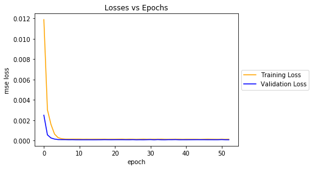

```python
nb_epoch = 300
batch_size = 256

model.fit(X_train, y_train, batch_size=batch_size, epochs=nb_epoch, verbose=1, validation_data=(X_valid, y_valid), callbacks=callbacks_list, shuffle=False)
```

```python
model.summary()
```

```
_________________________________________________________________
Layer (type)                 Output Shape              Param #
=================================================================
lstm_1 (LSTM)                (None, None, 50)          10400
_________________________________________________________________
dropout_1 (Dropout)          (None, None, 50)          0
_________________________________________________________________
lstm_2 (LSTM)                (None, 256)               314368
_________________________________________________________________
dropout_2 (Dropout)          (None, 256)               0
_________________________________________________________________
dense_1 (Dense)              (None, 1)                 257
_________________________________________________________________
activation_1 (Activation)    (None, 1)                 0
=================================================================
Total params: 325,025
Trainable params: 325,025
Non-trainable params: 0
_________________________________________________________________
```

### Load best weights

```python
model.load_weights("Predict_Share_Prices_model_weights_best.hdf5")
model.compile(loss='mean_squared_error', optimizer=optimizer)
```

```python
# generate predictions for training
train_predict = model.predict(X_train)
valid_predict = model.predict(X_valid)
test_predict = model.predict(X_test)
```

#### Plot - Predicted Values vs Actual

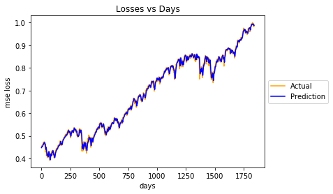

```python
plt.plot(y_test, color='orange')
plt.plot(test_predict, color='blue')


plt.title("Losses vs Days")
plt.ylabel("mse loss")
plt.xlabel("days")
plt.legend(['Actual','Prediction'],loc='center left', bbox_to_anchor=(1, 0.5))
```

### SP500 Dataset Training, Validation, and Testing Errors

```python
# print out training and testing errors
training_error = model.evaluate(X_train, y_train, verbose=0)
print('training error = ' + str(training_error))

validation_error = model.evaluate(X_valid, y_valid, verbose=0)
print('validation error = ' + str(validation_error))

testing_error = model.evaluate(X_test, y_test, verbose=0)
print('testing error = ' + str(testing_error))
```

```
training error = 4.07788942724e-05
validation error = 7.53448448197e-05
testing error = 0.000100467933841
```

```python
training_error_SP500 = training_error
validation_error_SP500 = validation_error
testing_error_SP500 = testing_error
```

```python
training_error_SP500, validation_error_SP500, testing_error_SP500
```

```
(4.0778894272379308e-05, 7.5344844819726439e-05, 0.00010046793384107296)
```

```python
### Plot Predicted vs Actual Values
```

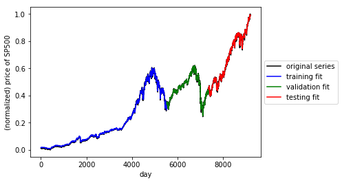

```python
plt.plot(dataset,color = 'k')

plt.plot(np.arange(window_size,len(train_predict) + window_size,1),train_predict,color = 'b')

plt.plot(np.arange(len(train_predict),len(train_predict) + len(valid_predict),1),valid_predict,color = 'g')

plt.plot(np.arange(len(train_predict) + len(valid_predict),len(train_predict) + len(valid_predict) + len(test_predict),1),test_predict[:,0],color = 'r')

plt.xlabel('day')
plt.ylabel('(normalized) price of SP500')
plt.legend(['original series','training fit','validation fit', 'testing fit'],loc='center left', bbox_to_anchor=(1, 0.5))
plt.show()
```

### Predicting one value at a time

```python
num = 1

x_test_initial = X_test_initial

preds = []

i = 0

while len(preds) + 1 < int(len(x_test_initial)/num):
    a_input_test = x_test_initial[i * num : (i + 1) * num]
    a_input_test = np.asarray(np.reshape(a_input_test, (num, window_size, 1)))

    pred = model.predict(a_input_test)
    #print("pred=",pred)
    preds.append(pred)


    replace_nums = min(num, window_size)

    for j in range(replace_nums):
        for k in range(j+1):
            x_test_initial[(i + 1) * num + j][window_size - 1 - j + k] = pred[k]
        #print(x_test_initial[(i + 1) * num + j])
    i += 1

y_preds=[]
for i in range(len(preds)):
    pred = preds[i]
    for j in range(len(pred)):
        y_preds.append(pred[j])

test_data_len = min(len(y_preds), len(y_test))
testScore = mean_squared_error(y_preds[:test_data_len], y_test[:test_data_len])
print('Test Score: %.8f MSE (%.8f RMSE)' % (testScore, np.sqrt(testScore)))
```

```
Test Score: 0.00011649 MSE (0.01079307 RMSE)
```

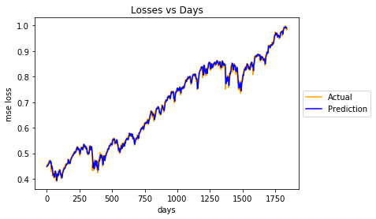

```python
#plt.plot(y_preds)
#plt.plot(y_test)

plt.plot(y_test, color='orange')
plt.plot(y_preds, color='blue')
plt.title("Losses vs Days")
plt.ylabel("mse loss")
plt.xlabel("days")
plt.legend(['Actual','Prediction'],loc='center left', bbox_to_anchor=(1, 0.5))
```

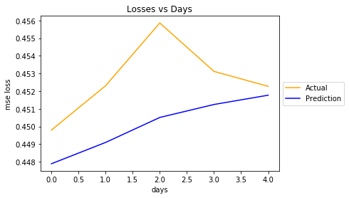

```python
plt.plot(y_test[:5], color='orange')
plt.plot(y_preds[:5], color='blue')
plt.title("Losses vs Days")
plt.ylabel("mse loss")
plt.xlabel("days")
plt.legend(['Actual','Prediction'],loc='center left', bbox_to_anchor=(1, 0.5))
```

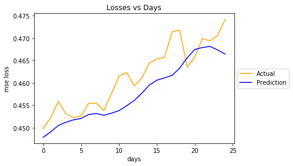

```python
plt.plot(y_test[:25], color='orange')
plt.plot(y_preds[:25], color='blue')
plt.title("Losses vs Days")
plt.ylabel("mse loss")
plt.xlabel("days")
plt.legend(['Actual','Prediction'],loc='center left', bbox_to_anchor=(1, 0.5))
```

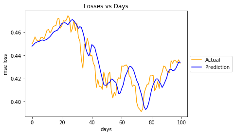

```python
plt.plot(y_test[:100], color='orange')
plt.plot(y_preds[:100], color='blue')
plt.title("Losses vs Days")
plt.ylabel("mse loss")
plt.xlabel("days")
plt.legend(['Actual','Prediction'],loc='center left', bbox_to_anchor=(1, 0.5))
```

### Predicting 5 values at a time

#### Using predicted values for predicted future values

```python
num = 5

x_test_initial = X_test_initial

preds = []

i = 0

while len(preds) + 1 < int(len(x_test_initial)/num):
    a_input_test = x_test_initial[i * num : (i + 1) * num]
    a_input_test = np.asarray(np.reshape(a_input_test, (num, window_size, 1)))

    pred = model.predict(a_input_test)
    #print("pred=",pred)

    preds.append(pred)


    replace_nums = min(num, window_size)

    for j in range(replace_nums):
        for k in range(j+1):
            x_test_initial[(i + 1) * num + j][window_size - 1 - j + k] = pred[k]
        #print(x_test_initial[(i + 1) * num + j])
    i += 1


y_preds=[]
for i in range(len(preds)):
    pred = preds[i]
    for j in range(len(pred)):
        y_preds.append(pred[j])

test_data_len = min(len(y_preds), len(y_test))
testScore = mean_squared_error(y_preds[:test_data_len], y_test[:test_data_len])
print('Test Score: %.8f MSE (%.8f RMSE)' % (testScore, np.sqrt(testScore)))
```

```
Test Score: 0.00021641 MSE (0.01471087 RMSE)
```

```python
test_data_len = min(len(y_preds), len(y_test))
testScore = mean_squared_error(y_preds[:test_data_len], y_test[:test_data_len])
print('Test Score: %.8f MSE (%.8f RMSE)' % (testScore, np.sqrt(testScore)))
```

```
Test Score: 0.00021641 MSE (0.01471087 RMSE)
```

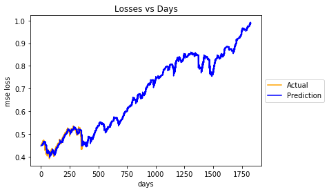

```python
plt.plot(y_test[:len(preds)], color='orange')
plt.plot(y_preds, color='blue')
plt.title("Losses vs Days")
plt.ylabel("mse loss")
plt.xlabel("days")
plt.legend(['Actual','Prediction'],loc='center left', bbox_to_anchor=(1, 0.5))
```

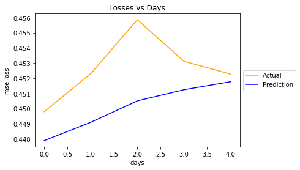

```python
plt.plot(y_test[:5], color='orange')
plt.plot(y_preds[:5], color='blue')
plt.title("Losses vs Days")
plt.ylabel("mse loss")
plt.xlabel("days")
plt.legend(['Actual','Prediction'],loc='center left', bbox_to_anchor=(1, 0.5))
```

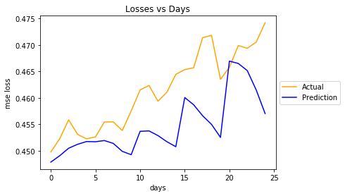

```python
plt.plot(y_test[:25], color='orange')
plt.plot(y_preds[:25], color='blue')
plt.title("Losses vs Days")
plt.ylabel("mse loss")
plt.xlabel("days")
plt.legend(['Actual','Prediction'],loc='center left', bbox_to_anchor=(1, 0.5))
```

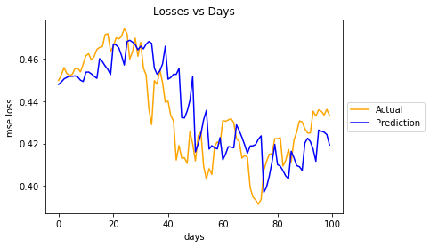

```python
plt.plot(y_test[:100], color='orange')
plt.plot(y_preds[:100], color='blue')
plt.title("Losses vs Days")
plt.ylabel("mse loss")
plt.xlabel("days")
plt.legend(['Actual','Prediction'],loc='center left', bbox_to_anchor=(1, 0.5))
```

### Predicting 25 values at a time

#### Using predicted values for predicted future values

```python
num = 25

x_test_initial = X_test_initial

preds = []

i = 0

while len(preds) + 1 < int(len(x_test_initial)/num):
    a_input_test = x_test_initial[i * num : (i + 1) * num]
    a_input_test = np.asarray(np.reshape(a_input_test, (num, window_size, 1)))

    pred = model.predict(a_input_test)

    preds.append(pred)

    #print(len(pred))
    #print("pred=",pred)

    index = int(num/window_size)
    #print("index = ",index)
    for j in range(index):
        for k in range(window_size):
            #print("j = ", j , " k = ",k)
            x_test_initial[(i + 1) * num + j][k] = pred[j * window_size + k]
        #print(x_test_initial[(i + 1) * num + j])

    i += 1

y_preds=[]
for i in range(len(preds)):
    pred = preds[i]
    for j in range(len(pred)):
        y_preds.append(pred[j])

test_data_len = min(len(y_preds), len(y_test))
testScore = mean_squared_error(y_preds[:test_data_len], y_test[:test_data_len])
print('Test Score: %.8f MSE (%.8f RMSE)' % (testScore, np.sqrt(testScore)))
```

```
Test Score: 0.00030682 MSE (0.01751634 RMSE)
```

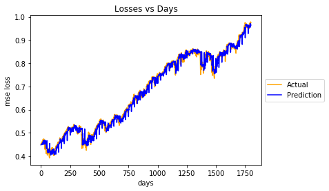

```python
plt.plot(y_test[:len(y_preds)], color='orange')
plt.plot(y_preds, color='blue')
plt.title("Losses vs Days")
plt.ylabel("mse loss")
plt.xlabel("days")
plt.legend(['Actual','Prediction'],loc='center left', bbox_to_anchor=(1, 0.5))
```

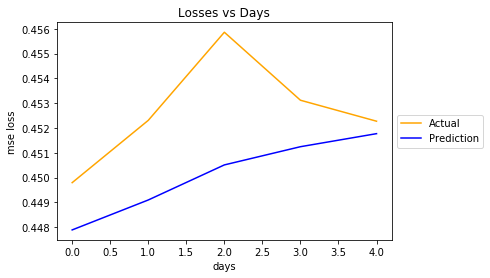

```python
plt.plot(y_test[:5], color='orange')
plt.plot(y_preds[:5], color='blue')
plt.title("Losses vs Days")
plt.ylabel("mse loss")
plt.xlabel("days")
plt.legend(['Actual','Prediction'],loc='center left', bbox_to_anchor=(1, 0.5))
```

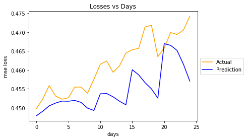

```python
plt.plot(y_test[:25], color='orange')
plt.plot(y_preds[:25], color='blue')
plt.title("Losses vs Days")
plt.ylabel("mse loss")
plt.xlabel("days")
plt.legend(['Actual','Prediction'],loc='center left', bbox_to_anchor=(1, 0.5))
```

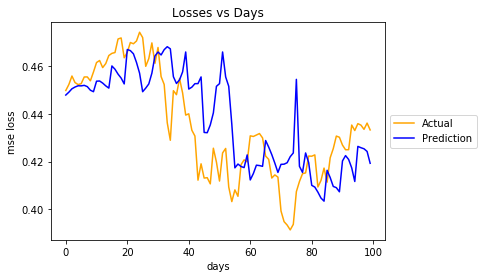

```python
plt.plot(y_test[:100], color='orange')
plt.plot(y_preds[:100], color='blue')
plt.title("Losses vs Days")
plt.ylabel("mse loss")
plt.xlabel("days")
plt.legend(['Actual','Prediction'],loc='center left', bbox_to_anchor=(1, 0.5))
```

### Above graphs show that if we use predicted values in future predictions, the predictions fall apart and correct results are only upto a few days. This happens because errors accumulate and trickles down to future values.

## Testing Model Robustness

### SP500 trained model is used to predict future values for other stocks

#### Results show that this model works quite well for all other stocks tested below.

### IBM

```
testing error = 0.000257458631247
```

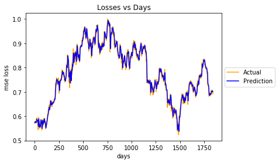

```python
X_test_IBM_reshaped = np.asarray(np.reshape(X_test_IBM, (X_test_IBM.shape[0], window_size, 1)))
test_predict_IBM = model.predict(X_test_IBM_reshaped)

testing_error_IBM = model.evaluate(X_test_IBM_reshaped, y_test_IBM, verbose=0)
print('testing error = ' + str(testing_error_IBM))

plt.plot(y_test_IBM, color='orange')
plt.plot(test_predict_IBM, color='blue')
plt.title("Losses vs Days")
plt.ylabel("mse loss")
plt.xlabel("days")
plt.legend(['Actual','Prediction'],loc='center left', bbox_to_anchor=(1, 0.5))
```

```python
training_error_SP500, validation_error_SP500, testing_error_SP500, testing_error_IBM
```

```
(4.0778894272379308e-05,
 7.5344844819726439e-05,
 0.00010046793384107296,
 0.00025745863124718139)
```

### MSFT

```
testing error = 0.00017958223662
```

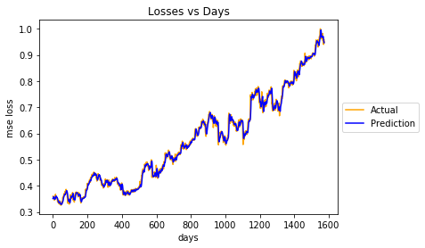

```python
X_test_MSFT_reshaped = np.asarray(np.reshape(X_test_MSFT, (X_test_MSFT.shape[0], window_size, 1)))
test_predict_MSFT = model.predict(X_test_MSFT_reshaped)

testing_error = model.evaluate(X_test_MSFT_reshaped, y_test_MSFT, verbose=0)
print('testing error = ' + str(testing_error))

#plt.plot(test_predict_MSFT)
#plt.plot(y_test_MSFT)

plt.plot(y_test_MSFT, color='orange')
plt.plot(test_predict_MSFT, color='blue')
plt.title("Losses vs Days")
plt.ylabel("mse loss")
plt.xlabel("days")
plt.legend(['Actual','Prediction'],loc='center left', bbox_to_anchor=(1, 0.5))
```